# Introduction to automated text analysis

Pablo Barbera

March 6, 2017

### String manipulation with R

We will start with basic string manipulation with R.

Our running example will be a random sample of 10,000 tweets mentioning the names of the candidates to the 2014 EP elections in the UK. We’ll save the text of these tweets as a vector called `text’

```r
tweets <- read.csv("data/EP-elections-tweets.csv", stringsAsFactors=F)
head(tweets)
```

```
##                                                                                                                                   text
## 1 @NSinclaireMEP Knew that Lib Dems getting into bed with Tories would end like this. They might never get another bite of the cherry.
## 2                               @Steven_Woolfe hi Steven, would you be free to join @LBC on the phone for 5 minutes after 3.30 at all?
## 3                                                                               @TrevorWAllman @Nigel_Farage The clock is ticking ....
## 4                                                                                                       @llexanderaamb got the badges.
## 5                                                                                          @Peebi @AnujaPrashar @Angel4theNorth thanks
## 6                                                      Well said @Nigel_Farage , poor Paxo had to change the subject.  #Gettingstuffed
##      screen_name           id   polite
## 1    martinwedge 4.730558e+17 impolite
## 2        WillGav 4.696599e+17   polite
## 3    CathyWood55 4.676486e+17   polite
## 4   CStephenssnp 4.701751e+17   polite
## 5 sanchia4europe 4.693720e+17   polite
## 6    EnglandsAce 4.685071e+17   polite
```

```r
text <- tweets$text
```

R stores the basic string in a character vector. `length` gets the number of items in the vector, while `nchar` is the number of characters in the vector.

```r
length(text)
```

```
## [1] 10000
```

```r
text[1]
```

```
## [1] "@NSinclaireMEP Knew that Lib Dems getting into bed with Tories would end like this. They might never get another bite of the cherry."
```

```r
nchar(text[1])
```

```
## [1] 132
```

Note that we can work with multiple strings at once.

```r
nchar(text[1:10])
```

```
##  [1] 132 102  54  30  43  79 140 137  94 139
```

```r
sum(nchar(text[1:10]))
```

```
## [1] 950
```

```r
max(nchar(text[1:10]))
```

```
## [1] 140
```

We can merge different strings into one using `paste`:

```r
paste(text[1], text[2], sep='--')
```

```
## [1] "@NSinclaireMEP Knew that Lib Dems getting into bed with Tories would end like this. They might never get another bite of the cherry.--@Steven_Woolfe hi Steven, would you be free to join @LBC on the phone for 5 minutes after 3.30 at all?"
```

Charcter vectors can be compared using the `==` and `%in%` operators:

```r
tweets$screen_name[1]=="martinwedge"
```

```
## [1] TRUE
```

```r
"DavidCoburnUKip" %in% tweets$screen_name
```

```
## [1] TRUE
```

As we will see later, it is often convenient to convert all words to lowercase or uppercase.

```r
tolower(text[1])
```

```
## [1] "@nsinclairemep knew that lib dems getting into bed with tories would end like this. they might never get another bite of the cherry."
```

```r
toupper(text[1])
```

```
## [1] "@NSINCLAIREMEP KNEW THAT LIB DEMS GETTING INTO BED WITH TORIES WOULD END LIKE THIS. THEY MIGHT NEVER GET ANOTHER BITE OF THE CHERRY."
```

We can grab substrings with `substr`. The first argument is the string, the second is the beginning index (starting from 1), and the third is final index.

```r
substr(text[1], 1, 2)
```

```
## [1] "@N"
```

```r
substr(text[1], 1, 10)
```

```
## [1] "@NSinclair"
```

This is useful when working with date strings as well:

```r
dates <- c("2015/01/01", "2014/12/01")
substr(dates, 1, 4) # years
```

```
## [1] "2015" "2014"
```

```r
substr(dates, 6, 7) # months
```

```
## [1] "01" "12"
```

We can split up strings by a separator using `strsplit`. If we choose space as the separator, this is in most cases equivalent to splitting into words.

```r
strsplit(text[1], " ")
```

```
## [[1]]
##  [1] "@NSinclaireMEP" "Knew"           "that"           "Lib"
##  [5] "Dems"           "getting"        "into"           "bed"
##  [9] "with"           "Tories"         "would"          "end"
## [13] "like"           "this."          "They"           "might"
## [17] "never"          "get"            "another"        "bite"
## [21] "of"             "the"            "cherry."
```

Let’s dit into the data a little bit more. Given the construction of the dataset, we can expect that there will be many tweets mentioning the names of the candidates, such as @Nigel_Farage, We can use the `grep` command to identify these. `grep` returns the index where the word occurs.

```r
grep('@Nigel_Farage', text[1:10])
```

```
## [1]  3  6  9 10
```

`grepl` returns `TRUE` or `FALSE`, indicating whether each element of the character vector contains that particular pattern.

```r
grepl('@Nigel_Farage', text[1:10])
```

```
##  [1] FALSE FALSE  TRUE FALSE FALSE  TRUE FALSE FALSE  TRUE  TRUE
```

Going back to the full dataset, we can use the results of `grep` to get particular rows. First, check how many tweets mention the handle "@Nigel_Farage".

```r
nrow(tweets)
```

```
## [1] 10000
```

```r
grep('@Nigel_Farage', tweets$text[1:10])
```

```
## [1]  3  6  9 10
```

```r
length(grep('@Nigel_Farage', tweets$text))
```

```
## [1] 1512
```

It is important to note that matching is case-sensitive. You can use the `ignore.case` argument to match to a lowercase version.

```r
nrow(tweets)
```

```
## [1] 10000
```

```r
length(grep('@Nigel_Farage', tweets$text))
```

```
## [1] 1512
```

```r
length(grep('@Nigel_Farage', tweets$text, ignore.case = TRUE))
```

```
## [1] 1535
```

### Regular expressions

Another useful tool to work with text data is called “regular expression”. You can learn more about regular expressions [here](http://www.zytrax.com/tech/web/regex.htm). Regular expressions let us develop complicated rules for both matching strings and extracting elements from them.

For example, we could look at tweets that mention more than one handle using the operator “|” (equivalent to “OR”)

```r
nrow(tweets)
```

```
## [1] 10000
```

```r
length(grep('@Nigel_Farage|@UKIP', tweets$text, ignore.case=TRUE))
```

```
## [1] 1739
```

We can also use question marks to indicate optional characters.

```r
nrow(tweets)
```

```
## [1] 10000
```

```r
length(grep('MEP?', tweets$text, ignore.case=TRUE))
```

```
## [1] 4461
```

This will match MEP, MEPs, etc.

Other common expression patterns are:

- `.` matches any character, `^` and `$` match the beginning and end of a string.
- Any character followed by `{3}`, `*`, `+` is matched exactly 3 times, 0 or more times, 1 or more times.
- `[0-9]`, `[a-zA-Z]`, `[:alnum:]` match any digit, any letter, or any digit and letter.
- Special characters such as `.`, `\`, `(` or `)` must be preceded by a backslash.
- See `?regex` for more details.

For example, how many tweets are direct replies to @Nigel_Farage? How many tweets are retweets? How many tweets mention any username?

```r
length(grep('^@Nigel_Farage', tweets$text, ignore.case=TRUE))
```

```
## [1] 376
```

```r
length(grep('^RT @', tweets$text, ignore.case=TRUE))
```

```
## [1] 47
```

```r
length(grep('@[A-Za-z0-9]+ ', tweets$text, ignore.case=TRUE))
```

```
## [1] 7834
```

Another function that we will use is `gsub`, which replaces a pattern (or a regular expression) with another string:

```r
gsub('@[0-9_A-Za-z]+', 'USERNAME', text[1])
```

```
## [1] "USERNAME Knew that Lib Dems getting into bed with Tories would end like this. They might never get another bite of the cherry."
```

To extract a pattern, and not just replace, use parentheses and choose the option `repl="\\1"`:

```r
gsub('.*@([0-9_A-Za-z]+) .*', text[1], repl="\\1")
```

```
## [1] "NSinclaireMEP"
```

You can make this a bit more complex using `gregexpr`, which will extract the location of the matches, and then `regmatches`

```r
handles <- gregexpr('@([0-9_A-Za-z]+)', text)
handles <- regmatches(text, handles)
handles <- unlist(handles)
head(sort(table(handles), decreasing=TRUE), n=25)
```

```
## handles
##    @Nigel_Farage  @nickgriffinmep            @UKIP @DavidCoburnUKip
##             1514              375              357              356
##      @JaniceUKIP  @RogerHelmerMEP    @DanHannanMEP @ClaudeMoraesMEP
##              241              234              228              123
##        @SebDance     @marcuschown        @Lucy4MEP @IvanaBartoletti
##              119              110              102               98
##  @Michael_Heaver   @TasminaSheikh   @maryhoneyball    @GreenJeanMEP
##               98               89               88               82
##   @TheGreenParty        @Tim_Aker     @JimAllister @MEPStandingUp4U
##               78               72               71               66
##  @GlenisWillmott  @sanchia4europe        @SLATUKIP  @davidmartinmep
##               62               62               61               57
##  @KamaljeetJandu
##               54
```

```r
# now with hashtags...
hashtags <- regmatches(text, gregexpr("#(\\d|\\w)+",text))
hashtags <- unlist(hashtags)
head(sort(table(hashtags), decreasing=TRUE), n=25)
```

```
## hashtags
##              #UKIP            #EP2014     #VoteGreen2014
##                261                146                 75
##                #EU             #bbcqt              #ukip
##                 57                 49                 44
##    #labourdoorstep #europeanelections     #votegreen2014
##                 40                 20                 20
##         #VoteLab14   #WhyImVotingUkip            #ep2014
##                 17                 17                 16
##        #Eurovision           #indyref          #Vote2014
##                 15                 15                 15
##             #bbcsp            #Labour        #votelabour
##                 14                 14                 14
##              #TUSC         #votegreen          #voteUKIP
##                 13                 13                 13
##            #London        #VoteLabour             #youth
##                 12                 12                 12
##               #SNP
##                 11
```

Now let’s try to identify what tweets are related to UKIP and try to extract them. How would we do it? First, let’s create a new column to the data frame that has value `TRUE` for tweets that mention this keyword and `FALSE` otherwise. Then, we can keep the rows with value `TRUE`.

```r
tweets$ukip <- grepl('ukip|farage', tweets$text, ignore.case=TRUE)
table(tweets$ukip)
```

```
##
## FALSE  TRUE
##  6968  3032
```

```r
ukip.tweets <- tweets[tweets$ukip==TRUE, ]
```

### Preprocessing text with quanteda

As we discussed earlier, before we can do any type of automated text analysis, we will need to go through several “preprocessing” steps before it can be passed to a statistical model. We’ll use the `quanteda` package quanteda here.

The basic unit of work for the `quanteda` package is called a `corpus`, which represents a collection of text documents with some associated metadata. Documents are the subunits of a corpus. You can use `summary` to get some information about your corpus.

```r
#install.packages("quanteda")
library(quanteda)
twcorpus <- corpus(tweets$text)
summary(twcorpus)
```

```
## Corpus consisting of 10000 documents, showing 100 documents.
##
##     Text Types Tokens Sentences
##    text1    24     25         2
##    text2    22     22         1
##    text3     7     10         1
##    text4     5      5         1
##    text5     4      4         1
##    text6    13     13         1
##    text7    25     26         3
##    text8    21     23         1
##    text9    16     18         2
##   text10    26     29         1
##   text11    22     24         3
##   text12     7      8         1
##   text13    23     24         1
##   text14    17     18         1
##   text15    26     27         3
##   text16    24     26         2
##   text17    20     29         1
##   text18    15     16         1
##   text19    20     22         2
##   text20    20     20         2
##   text21    27     31         2
##   text22    21     23         1
##   text23    10     10         1
##   text24    20     22         2
##   text25    13     13         1
##   text26    12     12         1
##   text27     9     11         1
##   text28     3      3         1
##   text29    16     27         1
##   text30    10     10         2
##   text31     4      4         1
##   text32    22     24         6
##   text33     3      3         1
##   text34     9      9         1
##   text35    12     14         1
##   text36    17     18         2
##   text37    14     14         2
```

[output cut: 52 more lines]

```
##   text90    15     16         1
##   text91    20     23         1
##   text92    19     23         2
##   text93    16     22         2
##   text94    25     29         2
##   text95    20     22         1
##   text96    22     24         4
##   text97    13     17         2
##   text98    16     18         2
##   text99    25     28         3
##  text100    23     26         1
##
## Source:  /Users/pablobarbera/git/training/* on x86_64 by pablobarbera
## Created: Tue Mar  7 10:17:11 2017
## Notes:
```

A useful feature of corpus objects is *keywords in context*, which returns all the appearances of a word (or combination of words) in its immediate context.

```r
kwic(twcorpus, "brexit", window=10)
```

```
##
## [text7905, 7] @2cvdolly1 I'll make the case for | Brexit |
##
## [text7905, 7] to the best of my ability. I genuinely believe
```

```r
kwic(twcorpus, "miliband", window=10)
```

```
##
## [text1072, 2]                                                                                                                Ed
## [text2859, 6]                                                                                         RT"@steverichards14: It's
## [text3757, 4]                                                                                                      Watch out Ed
## [text4300, 3]                                                                                                       Here's what
## [text4863, 2]                                                                                                                Ed
## [text5150, 6]                                                                   @petercoles44@DavidCoburnUKip@Ed_Miliband To me
## [text5251, 4]                                                                                                      Watch out Ed
## [text5294, 4]                                                                                                      Watch out Ed
## [text5376, 10] @PrzSkwirczynski@State_Control@WinstonMcK@croydon_oldtown@suzanneshine@hopenothate@SLATUKIP@SquareBiz_T@bieneosa
## [text6042, 1]
## [text6089, 4]                                                                                                      Watch out Ed
## [text6291, 2]                                                                                                                Ed
## [text7458, 12]                                                 @UKIP_Bolton@Nigel_Farage UKIP ain't racist Mr's Cameron/ Clegg/
## [text7988, 12]                                                 @UKIP_Bolton@Nigel_Farage UKIP ain't racist Mr's Cameron/ Clegg/
## [text8075, 28]                                                                          imagine what he can do to cameron& amp;
## [text9746, 2]                                                                                                                Ed
##
## [text1072, 2]  | Miliband |
## [text2859, 6]  | Miliband |
## [text3757, 4]  | Miliband |
## [text4300, 3]  | Miliband |
## [text4863, 2]  | Miliband |
## [text5150, 6]  | Miliband |
## [text5251, 4]  | Miliband |
## [text5294, 4]  | Miliband |
## [text5376, 10] | Miliband |
## [text6042, 1]  | Miliband |
## [text6089, 4]  | Miliband |
## [text6291, 2]  | Miliband |
## [text7458, 12] | Miliband |
## [text7988, 12] | Miliband |
## [text8075, 28] | miliband |
## [text9746, 2]  | Miliband |
##
## [text1072, 2]  , please cap gym prices http:// t.co
## [text2859, 6]  , not Farage, who's breaking with tradition and upsetting
## [text3757, 4]  : Nigel Farage and Ukip targets Labour( via@daily_express
## [text4300, 3]  had to say about standing up to UKIP- http
## [text4863, 2]  , please cap gym prices http:// t.co
## [text5150, 6]  looks a shifty character with normal people
## [text5251, 4]  : Nigel Farage and Ukip targets Labour( via@daily_express
## [text5294, 4]  : Nigel Farage and Ukip targets Labour( via@daily_express
## [text5376, 10] apologise!
## [text6042, 1]  saying he wants to hear where#UKIP stands on key
## [text6089, 4]  : Nigel Farage and Ukip targets Labour( via@daily_express
## [text6291, 2]  is heading for disaster as Labour MPs say party leaders
## [text7458, 12] Sticks& amp; Stones Two VOTES ukip http:
## [text7988, 12] Sticks& amp; Stones Two VOTES ukip http:
## [text8075, 28]
## [text9746, 2]  is heading for disaster as Labour MPs say party leaders
```

```r
kwic(twcorpus, "eu referendum", window=10)
```

```
##
## [text5316, 18:19]                                 , why wait for 2017 for an in/ out
## [text5756, 18:19]                                 , why wait for 2017 for an in/ out
## [text6906, 12:13] @Nigel_Farage What happened to#Cameron's cast iron guarantee of an
## [text9038, 12:13] @Nigel_Farage What happened to#Cameron's cast iron guarantee of an
##
## [text5316, 18:19] | EU referendum | - If EU renegotiation impossible?
## [text5756, 18:19] | EU referendum | - If EU renegotiation impossible?
## [text6906, 12:13] | EU referendum | before the last election?#bbcsp
## [text9038, 12:13] | EU referendum | before the last election?#bbcsp
```

We can then convert a corpus into a document-feature matrix using the `dfm` function.

```r
twdfm <- dfm(twcorpus)
```

`dfm` has many useful options. Let’s actually use it to stem the text, extract n-grams, remove punctuation, keep Twitter features…

```r
?dfm
twdfm <- dfm(twcorpus, tolower=TRUE, stem=TRUE, removePunct = TRUE, ngrams=c(1,3))
```

Stemming relies on the `SnowballC` package’s implementation of the Porter stemmer:

```r
tokenize(tweets$text[1])
```

```
## tokenizedTexts from 1 document.
## Component 1 :
##  [1] "@NSinclaireMEP" "Knew"           "that"           "Lib"
##  [5] "Dems"           "getting"        "into"           "bed"
##  [9] "with"           "Tories"         "would"          "end"
## [13] "like"           "this"           "."              "They"
## [17] "might"          "never"          "get"            "another"
## [21] "bite"           "of"             "the"            "cherry"
## [25] "."
```

```r
tokens_wordstem(tokenize(tweets$text[1]))
```

```
## tokenizedTexts from 1 document.
## Component 1 :
##  [1] "@NSinclaireMEP" "Knew"           "that"           "Lib"
##  [5] "Dem"            "get"            "into"           "bed"
##  [9] "with"           "Tori"           "would"          "end"
## [13] "like"           "thi"            "."              "Thei"
## [17] "might"          "never"          "get"            "anoth"
## [21] "bite"           "of"             "the"            "cherri"
## [25] "."
```

In a large corpus like this, many features often only appear in one or two documents. In some case it’s a good idea to remove those features, to speed up the analysis or because they’re not relevant. We can `trim` the dfm:

```r
twdfm <- dfm_trim(twdfm, min_docfreq=3)
```

It’s often a good idea to take a look at a wordcloud of the most frequent features to see if there’s anything weird.

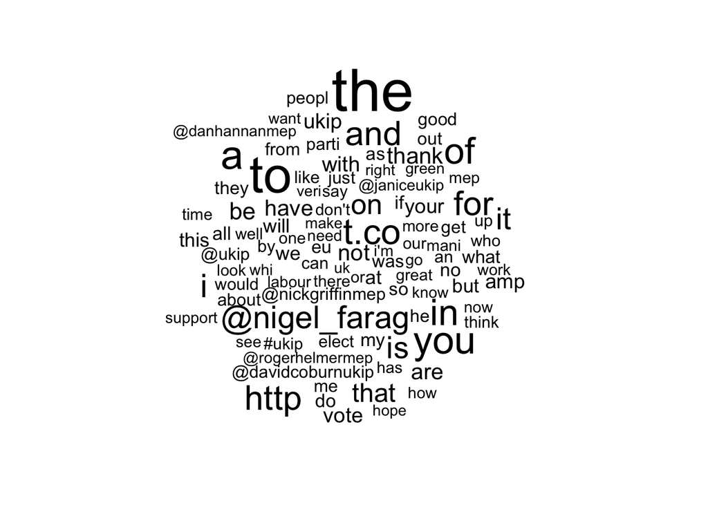

```r
textplot_wordcloud(twdfm, rot.per=0, scale=c(3.5, .75), max.words=100)
```

What is going on? We probably want to remove words and symbols which are not of interest to our data, such as http here. This class of words which is not relevant are called stopwords. These are words which are common connectors in a given language (e.g. “a”, “the”, “is”). We can also see the list using `topFeatures`

```r
topfeatures(twdfm, 25)
```

```
##          the           to            a          you           of
##         3731         3090         2259         2136         1950
##           in         t.co         http          and          for
##         1950         1863         1744         1718         1706
##            i @nigel_farag           is           it           on
##         1616         1533         1475         1452         1277
##         that           be        thank          not          are
##         1099          919          849          828          800
##         have         with         ukip         vote          amp
##          790          719          690          684          644
```

We can remove the stopwords when we create the `dfm` object:

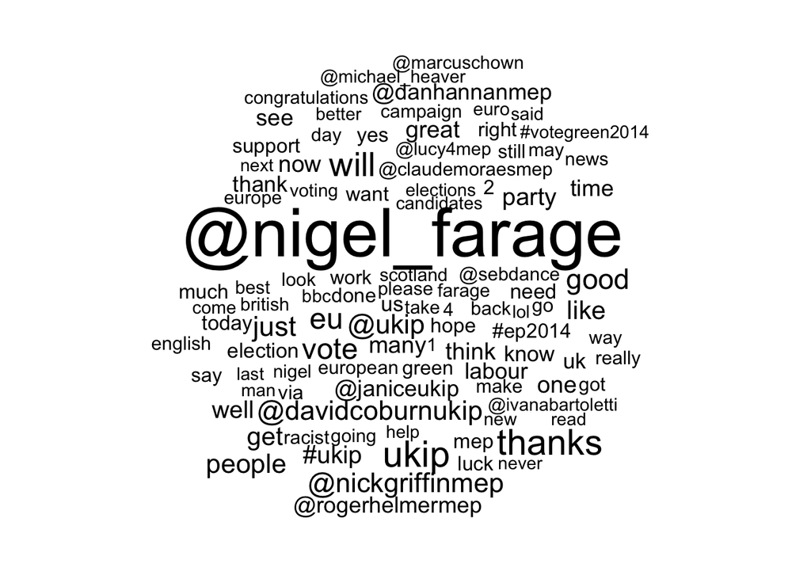

```r
twdfm <- dfm(twcorpus, removePunct = TRUE, remove=c(
  stopwords("english"), "t.co", "https", "rt", "amp", "http", "t.c", "can", "u"))
textplot_wordcloud(twdfm, rot.per=0, scale=c(3.5, .75), max.words=100)
```

One nice feature of quanteda is that we can easily add metadata to the corpus object.

```r
docvars(twcorpus) <- data.frame(screen_name=tweets$screen_name, polite=tweets$polite)
summary(twcorpus)
```

```
## Corpus consisting of 10000 documents, showing 100 documents.
##
##     Text Types Tokens Sentences     screen_name   polite
##    text1    24     25         2     martinwedge impolite
##    text2    22     22         1         WillGav   polite
##    text3     7     10         1     CathyWood55   polite
##    text4     5      5         1    CStephenssnp   polite
##    text5     4      4         1  sanchia4europe   polite
##    text6    13     13         1     EnglandsAce   polite
##    text7    25     26         3   MikeGreenUKIP   polite
##    text8    21     23         1    Anothergreen   polite
##    text9    16     18         2         kell901   polite
##   text10    26     29         1 BranimiraMachev   polite
##   text11    22     24         3      NorseFired   polite
##   text12     7      8         1  CharlesTannock   polite
##   text13    23     24         1    GoodallGiles   polite
##   text14    17     18         1 francisdolarhy2   polite
##   text15    26     27         3    CuinnUiNeill   polite
##   text16    24     26         2   HenryMcMorrow   polite
##   text17    20     29         1 DavidCoburnUKip   polite
##   text18    15     16         1        ajcdeane   polite
##   text19    20     22         2      jackbuckby   polite
##   text20    20     20         2       kvmarthur   polite
##   text21    27     31         2  YOURvoiceParty   polite
##   text22    21     23         1       101flyboy   polite
##   text23    10     10         1  CharlesTannock   polite
##   text24    20     22         2    DuncanRights   polite
##   text25    13     13         1  skepticalvoter   polite
##   text26    12     12         1 DavidCoburnUKip   polite
##   text27     9     11         1  scrapperduncan   polite
##   text28     3      3         1       zander469   polite
##   text29    16     27         1   DavidWickham3   polite
##   text30    10     10         2  Green_Caroline   polite
##   text31     4      4         1    GucciAirbag_   polite
##   text32    22     24         6       Comrade58 impolite
##   text33     3      3         1 DugaldMacMillan   polite
##   text34     9      9         1        Shyman33   polite
##   text35    12     14         1      jackbuckby   polite
##   text36    17     18         2    cymroynewrop   polite
##   text37    14     14         2 danielrhamilton   polite
```

[output cut: 52 more lines]

```
##   text90    15     16         1    AlynSmithMEP   polite
##   text91    20     23         1    suzanneshine   polite
##   text92    19     23         2   ssilverwavess   polite
##   text93    16     22         2   GlobalYawning   polite
##   text94    25     29         2      CulliganPA   polite
##   text95    20     22         1   CllrChrisPain   polite
##   text96    22     24         4    dennisterrey impolite
##   text97    13     17         2    Anothergreen   polite
##   text98    16     18         2      FionaRadic   polite
##   text99    25     28         3    cristian7897   polite
##  text100    23     26         1 jennyknight2014   polite
##
## Source:  /Users/pablobarbera/git/training/* on x86_64 by pablobarbera
## Created: Tue Mar  7 10:17:11 2017
## Notes:
```

We can then use this metadata to subset the dataset:

```r
polite.tweets <- corpus_subset(twcorpus, polite=="impolite")
```

And then extract the text:

```r
mytexts <- texts(polite.tweets)
```

We’ll come back later to this dataset.

### Importing text with quanteda

There are different ways to read text into `R` and create a `corpus` object with `quanteda`. We have already seen the most common way, importing the text from a csv file and then adding the metadata, but `quanteda` has a built-in function to help with this:

```r
#devtools::install_github("kbenoit/readtext")
library(readtext)
tweets <- readtext(file='data/EP-elections-tweets.csv')
twcorpus <- corpus(tweets)
```

```r
myCorpus <- readtext(file='data/inaugural/*.txt')
inaugCorpus <- corpus(myCorpus)
```